# Summary Report of KMeans on Holiday Dataset

Team B : Achal, Gupta —————A00258772

5 April 2019

# Data Set Information:

This dataset was populated from destination reviews published by 249 reviewers of holidayiq.com till October 2014. Reviews falling in 6 categories among destinations across South India were considered and the count of reviews in each category for every reviewer (traveler) is captured.

# Attribute Information

Attribute 1 : Unique user id  
Attribute 2 : Number of reviews on stadiums, sports complex, etc.  
Attribute 3 : Number of reviews on religious institutions  
Attribute 4 : Number of reviews on beach, lake, river, etc.  
Attribute 5 : Number of reviews on theatres, exhibitions, etc.  
Attribute 6 : Number of reviews on malls, shopping places, etc.  
Attribute 7 : Number of reviews on parks, picnic spots, etc.

#### Scaling data

Visualizing data distribution before scaling using boxplot

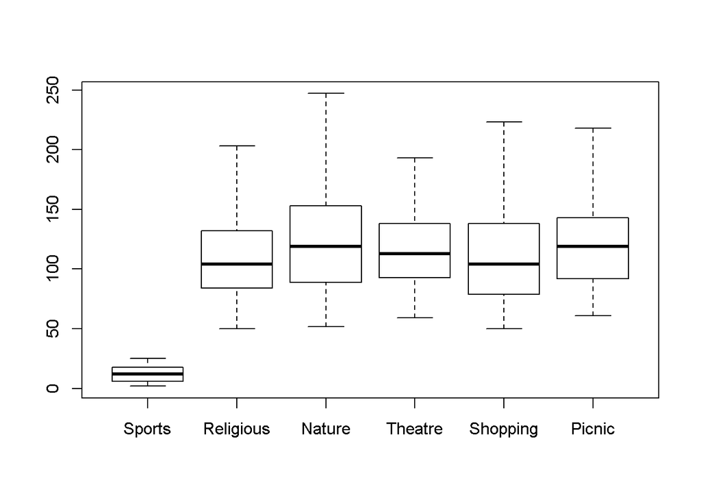

Since clustering algorithms including kmeans use distance-based measurements to determine the similarity between data points, it’s recommended to standardize the data to have a mean of zero and a standard deviation of one since almost always the features in any dataset would have different units of measurements.

Visualizing data distribution after scaling

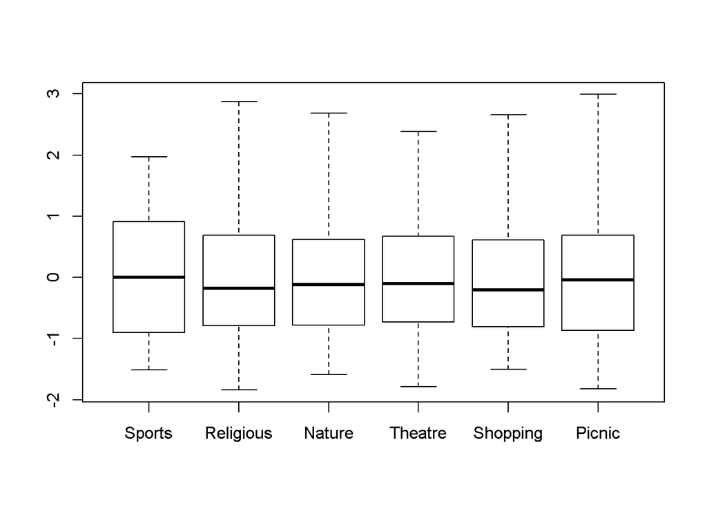

### Descriptive Analysis

#### Top 5 active users based on total reviews given

Visualize Top 5 active users using bar graph

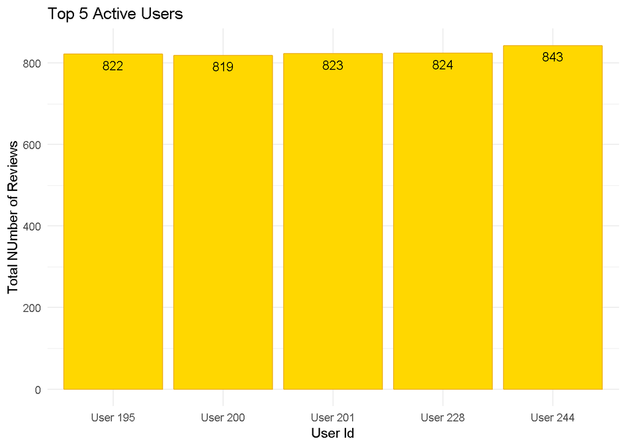

#### Top 5 shopaholics users

Bar graph to repreent users who shop most

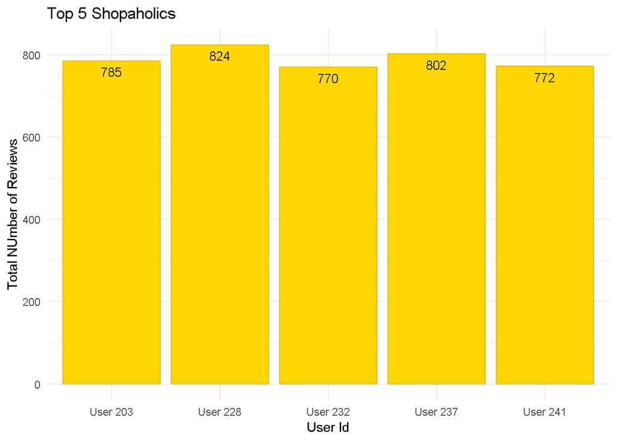

Graph below will perform three analysis  
1. Distribution of data for each feature or column shown using a histogram.  
2. Correlation coefficients for each combination of feature  
3. Scatterplot with fit line to visualize correlation

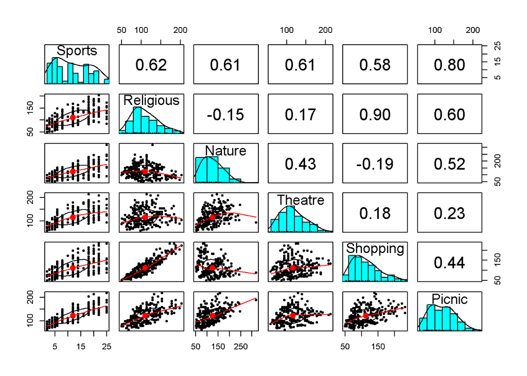

**Key Observations** 1. Number of shopping reviews has a strong positive relation with number of relegious destination reviews.  
2. Number of reviews by user for Shopping and Nature destinations shows weak negative corelation  
3. Number of reviews by user for Relegious and Nature destinations shows weak negative corelation  
4. Number of reviews by user for Nature and Theatre destinations shows weak positive corelation.

#### K Means Clustering

##### Identify best value of K

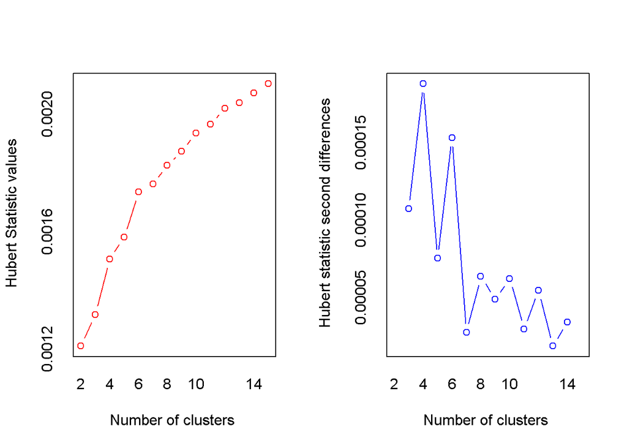

```
## *** : The Hubert index is a graphical method of determining the number of clusters.
##                 In the plot of Hubert index, we seek a significant knee that corresponds to a
##                 significant increase of the value of the measure i.e the significant peak in Hubert
##                 index second differences plot.
##
```

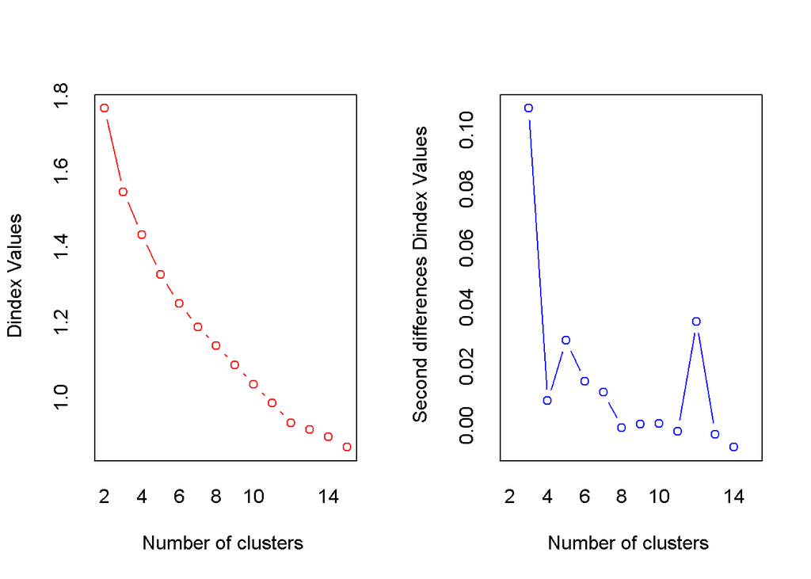

```
## *** : The D index is a graphical method of determining the number of clusters.
##                 In the plot of D index, we seek a significant knee (the significant peak in Dindex
##                 second differences plot) that corresponds to a significant increase of the value of
##                 the measure.
##
## * Among all indices:
## * 7 proposed 2 as the best number of clusters
## * 7 proposed 3 as the best number of clusters
## * 1 proposed 4 as the best number of clusters
## * 1 proposed 5 as the best number of clusters
## * 1 proposed 6 as the best number of clusters
## * 2 proposed 12 as the best number of clusters
## * 1 proposed 13 as the best number of clusters
## * 3 proposed 15 as the best number of clusters
##
##                    ***** Conclusion *****
##
## * According to the majority rule, the best number of clusters is  2
##
##
```

```
##
##  0  1  2  3  4  5  6 12 13 15
##  2  1  7  7  1  1  1  2  1  3
```

K= 2 and 3 both shows maximum values, geneally an odd value for k is preffered and hence k=3 is optimumu value.

Let’s make model using both values and evaluate.

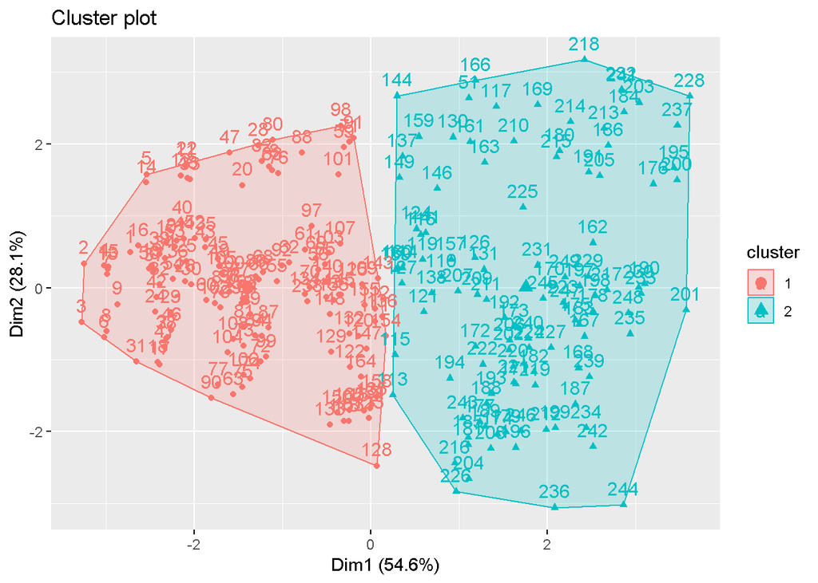

Table of average of various columns for each cluster

```
##   cluster    Sports Religious   Nature  Theatre  Shopping    Picnic
## 1       1  7.014388   90.1223 109.2374 103.6475  89.56115  99.09353
## 2       2 18.272727  134.6182 143.8273 132.4636 141.80000 147.32727
```

Not much insight can be gathered from 2 clusters it just divide data into two categories user with less reviews on all groups i.e. new users and people with more reviews i.e outgoing or active users

Lets crete cluster with more than 2 groups i.e. Building cluster with k=3

Analysing the cluster

```
## K-means clustering with 3 clusters of sizes 97, 39, 113
##
## Cluster means:
##       Sports  Religious     Nature    Theatre    Shopping     Picnic
## 1  0.8291808  0.1205272  0.9272034  0.7361168  0.04714263  0.6940736
## 2  0.5947442  1.6082781 -0.8316059 -0.1825147  1.66821431  0.5620627
## 3 -0.9170403 -0.6585309 -0.5089035 -0.5688961 -0.61622295 -0.7897840
##
## Clustering vector:
##   [1] 3 3 3 3 3 3 3 3 3 3 3 3 3 3 3 3 3 3 3 3 3 3 3 3 3 3 3 3 3 3 3 3 3 3 3
##  [36] 3 3 3 3 3 3 3 3 3 3 3 3 3 3 3 2 3 3 3 3 3 3 3 2 3 3 3 3 3 3 3 3 3 3 3
##  [71] 2 3 3 3 3 3 3 3 3 3 3 3 3 3 3 3 3 3 3 3 2 3 3 3 3 3 3 2 3 3 3 3 3 3 3
## [106] 3 3 3 3 1 1 1 1 1 1 2 2 1 1 1 1 1 1 2 3 1 1 1 3 2 1 1 1 3 1 1 2 1 1 3
## [141] 2 3 1 2 3 2 1 3 2 1 1 1 1 1 1 3 1 1 2 1 2 2 2 1 1 2 1 1 2 1 1 1 1 1 1
## [176] 2 1 1 1 2 1 1 1 2 1 2 1 1 1 1 2 1 1 1 2 1 1 1 1 2 1 1 2 1 2 1 1 1 1 2
## [211] 1 1 2 2 2 1 1 2 1 1 1 1 1 1 2 1 1 2 1 1 1 2 1 1 1 1 2 3 1 1 2 1 1 1 1
## [246] 1 1 1 1
##
## Within cluster sum of squares by cluster:
## [1] 330.76311  96.53409 222.64518
##  (between_SS / total_SS =  56.3 %)
##
## Available components:
##
## [1] "cluster"      "centers"      "totss"        "withinss"
## [5] "tot.withinss" "betweenss"    "size"         "iter"
## [9] "ifault"
```

Above output shows the sizes of three clusters formed along with the mean value for each column for each cluster.  
Then the output displays a vector of cluster value for each row.  
Within cluster sum of squares is displayed for each of the three clusters.

```
## List of 9
##  $ cluster     : int [1:249] 3 3 3 3 3 3 3 3 3 3 ...
##  $ centers     : num [1:3, 1:6] 0.829 0.595 -0.917 0.121 1.608 ...
##   ..- attr(*, "dimnames")=List of 2
##   .. ..$ : chr [1:3] "1" "2" "3"
##   .. ..$ : chr [1:6] "Sports" "Religious" "Nature" "Theatre" ...
##  $ totss       : num 1488
##  $ withinss    : num [1:3] 330.8 96.5 222.6
##  $ tot.withinss: num 650
##  $ betweenss   : num 838
##  $ size        : int [1:3] 97 39 113
##  $ iter        : int 3
##  $ ifault      : int 0
##  - attr(*, "class")= chr "kmeans"
```

Above output displays following information  
**Cluster:** A vector of integers (from 1:k) indicating the cluster to which each point is allocated.  
**Centers:** A matrix of cluster centers.  
**totss:** The total sum of squares.  
**withinss:** Vector of within-cluster sum of squares, one component per cluster.  
**tot.withinss:** Total within-cluster sum of squares, i.e. sum(withinss).  
**betweenss:** The between-cluster sum of squares, i.e. $totss-tot.withinss$.  
**size:** The number of points in each cluster

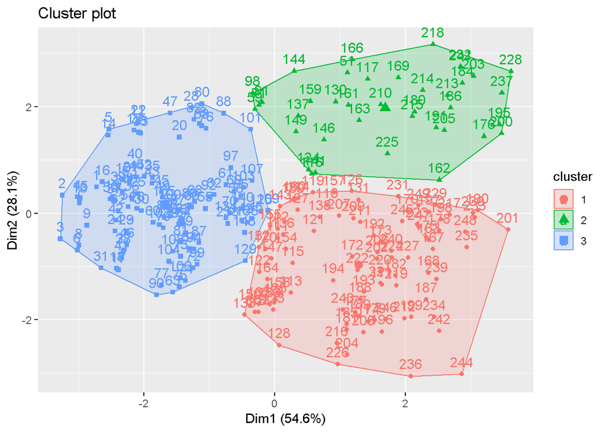

Creating table of average of various columns for each cluster

```
##   cluster    Sports Religious   Nature   Theatre  Shopping    Picnic
## 1       1 17.474227 113.69072 166.8351 140.03093 114.59794 143.05155
## 2       2 15.923077 161.97436  86.5641 110.51282 181.97436 138.74359
## 3       3  5.920354  88.40708 101.2920  98.09735  87.02655  94.62832
```

Visualizing clusters for various combination of scatterplots

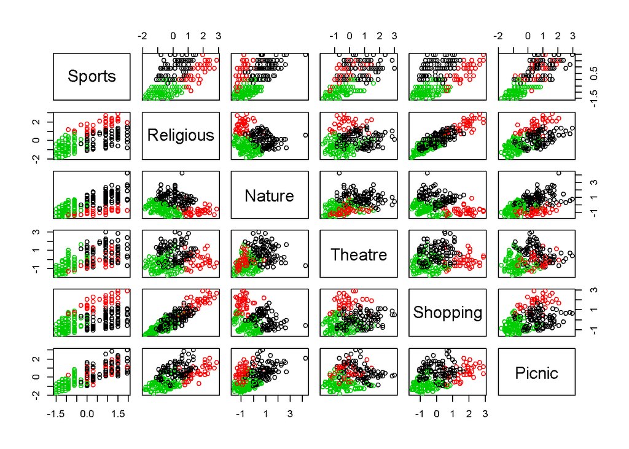

Focusing on some major insights: Assuming less number of reviews by a user on a particular destination means user visit that destination group less number of times. People who visit more relegious institutions tends to do more shopping reviews as can be viewed from the plot below

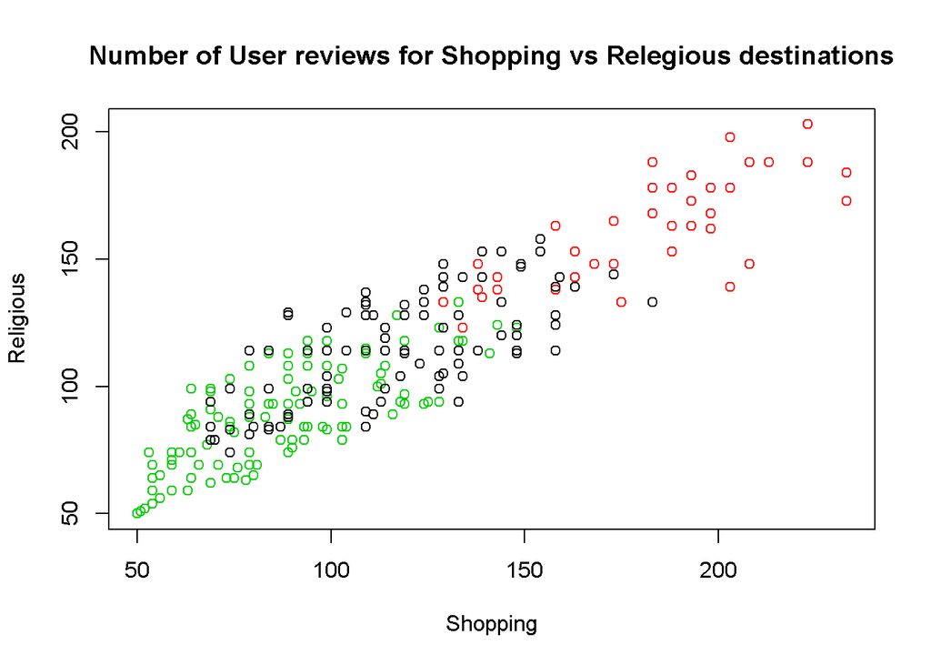

People who are nature lovers do less shopping as can be viewed from the plot below

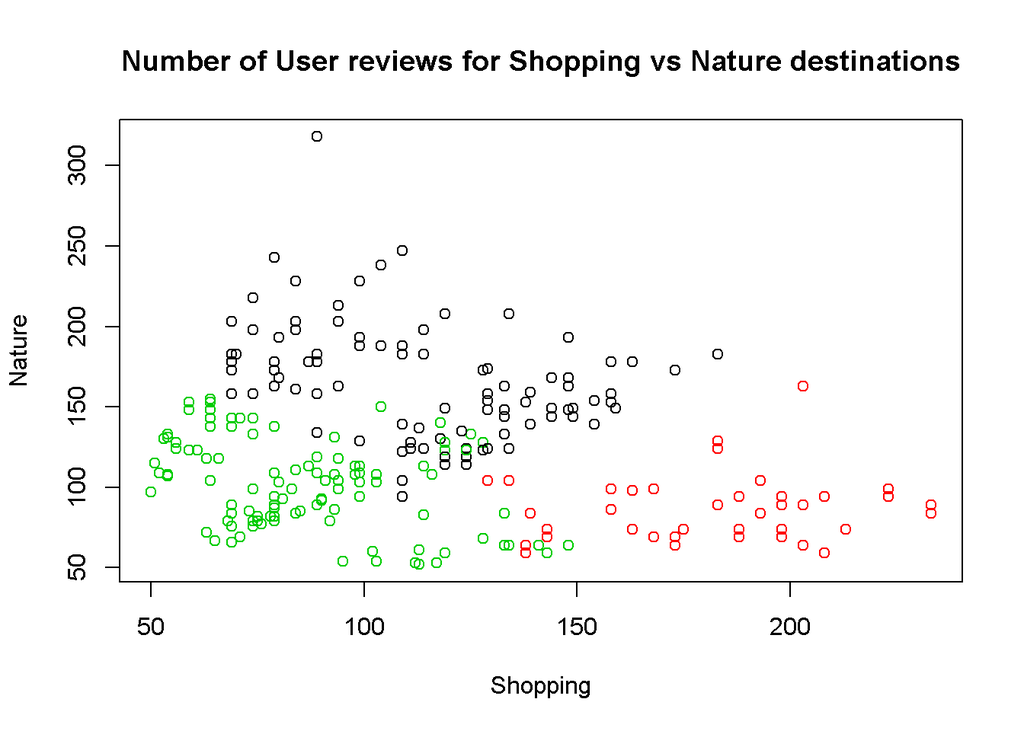

People who are nature lovers are more into Theatre destinations as can be viewed from the plot below

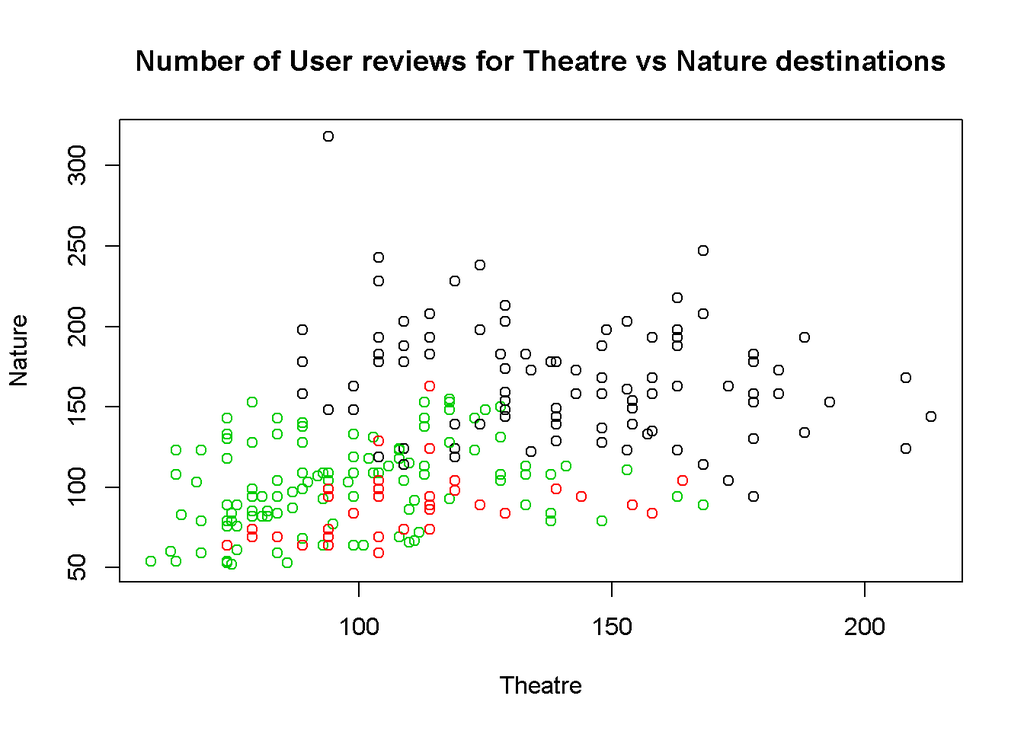